# R Notebook

11H2. The data contained in library(MASS);data(eagles) are records of salmon pirating attempts by Bald Eagles in Washington State. See ?eagles for details. While one eagle feeds, sometimes another will swoop in and try to steal the salmon from it. Call the feeding eagle the “victim” and the thief the “pirate.” Use the available data to build a binomial GLM of successful pirating attempts.

1. Consider the following model:

yi~Binomial(ni,pi) logit(pi)=α+βPPi+βVVi+βAAi α~Normal(0,1.5) βP,βV,βA~Normal(0,0.5)

where y is the number of successful attempts, n is the total number of attempts, P is a dummy variable indicating whether or not the pirate had large body size, V is a dummy variable indicating whether or not the victim had large body size, and finally A is a dummy variable indicating whether or not the pirate was an adult. Fit the model above to the eagles data, using both quap and ulam. Is the quadratic approximation okay?

**First, we need to make some 0/1 variables for the categorical variables P, A, and V in the data frame. Name them whatever you like, but here are my choices:**

```r
library(rethinking)
library(MASS)
data(eagles)
d <- eagles
d$pirateL <- ifelse( d$P=="L" , 1 , 0 )
d$victimL <- ifelse( d$V=="L" , 1 , 0 )
d$pirateA <- ifelse( d$A=="A" , 1 , 0 )
```

**Now to fit the model both ways. I’m going use the standard intercept prior here, and a only slighter narrow prior for each coefficient. This allows for large effects.**

```r
f <- alist(
y ~ dbinom( n , p ),
logit(p) <- a + bP*pirateL + bV*victimL + bA*pirateA ,
a ~ dnorm(0,1.5),
bP ~ dnorm(0,1),
bV ~ dnorm(0,1),
bA ~ dnorm(0,1) )
m1 <- quap( f , data=d )
m1_stan <- ulam( f , data=d , chains=4 , log_lik=TRUE )
```

[output not shown]

```r
precis(m1)
```

|  | mean | sd | 5.5% | 94.5% |
| --- | --- | --- | --- | --- |
| a | 0.3506134 | 0.4793414 | -0.4154667 | 1.116694 |
| bP | 2.5810979 | 0.4373686 | 1.8820984 | 3.280097 |
| bV | -2.7109741 | 0.4703913 | -3.4627503 | -1.959198 |
| bA | 0.8921615 | 0.4065891 | 0.2423537 | 1.541969 |

```r
precis(m1_stan)
```

|  | mean | sd | 5.5% | 94.5% | rhat | ess_bulk |
| --- | --- | --- | --- | --- | --- | --- |
| a | 0.3638053 | 0.4431303 | -0.3475842 | 1.066736 | 1.003567 | 1180.662 |
| bP | 2.6583428 | 0.4259383 | 1.9913167 | 3.363178 | 1.003557 | 1311.478 |
| bV | -2.7870805 | 0.4705212 | -3.5604535 | -2.034938 | 1.006949 | 1302.711 |
| bA | 0.9166548 | 0.3954638 | 0.3021708 | 1.570569 | 1.001464 | 1280.341 |

```r
f<- alist(
y ~ dbinom( n , p ),
logit(p) <- a + bP*pirateL + bV*victimL + bA*pirateA ,
a ~ dnorm(0,10),
bP ~ dnorm(0,10),
bV ~ dnorm(0,10),
bA ~ dnorm(0,10) )
```

[output not shown]

```r
precis(m1)
```

|  | mean | sd | 5.5% | 94.5% |
| --- | --- | --- | --- | --- |
| a | 0.3506134 | 0.4793414 | -0.4154667 | 1.116694 |
| bP | 2.5810979 | 0.4373686 | 1.8820984 | 3.280097 |
| bV | -2.7109741 | 0.4703913 | -3.4627503 | -1.959198 |
| bA | 0.8921615 | 0.4065891 | 0.2423537 | 1.541969 |

```r
precis(m1_stan)
```

|  | mean | sd | 5.5% | 94.5% | rhat | ess_bulk |
| --- | --- | --- | --- | --- | --- | --- |
| a | 0.3638053 | 0.4431303 | -0.3475842 | 1.066736 | 1.003567 | 1180.662 |
| bP | 2.6583428 | 0.4259383 | 1.9913167 | 3.363178 | 1.003557 | 1311.478 |
| bV | -2.7870805 | 0.4705212 | -3.5604535 | -2.034938 | 1.006949 | 1302.711 |
| bA | 0.9166548 | 0.3954638 | 0.3021708 | 1.570569 | 1.001464 | 1280.341 |

**Again, with GLMs the existence of ceiling and floor effects makes quadratic approximation risky.**

2. Now interpret the estimates. If the quadratic approximation turned out okay, then it’s okay to use the quap estimates. Otherwise stick to ulam estimates. Then plot the posterior predictions. Compute and display both (1) the predicted probability of success and its 89% interval for each row (i) in the data, as well as (2) the predicted success count and its 89% interval. What different information does each type of posterior prediction provide?

```r
post <- extract.samples( m1_stan )
quantile( logistic( post$a ) , probs=c(0.055,0.5,0.945) )
```

```
##      5.5%       50%     94.5%
## 0.4139684 0.5894072 0.7439756
```

**A little under 60% of attempts by immature small pirates on small victims are expected to succeed. Note the way I did the calculation above. First the logistic transform is performed for every sample, and then the summary is made. Always summarize last. The mean of a function is not the same as the function of the mean! So what about the slope (β) estimates? These estimates just change the intercept for the log-odds. So for example, the probability that a large immature pirate succeeds against a small victim would be:**

```r
quantile( logistic( post$a + post$bP ) , probs=c(0.055,0.5,0.945) )
```

```
##      5.5%       50%     94.5%
## 0.9013936 0.9527193 0.9795026
```

**That is to say, the large pirate is almost certain to succeed, according to the model. You can generate such predictions for all of the combinations, if you wish. And indeed, that’s how the plotting of predictions works. There are many ways to plot the posterior predictions. I’ll use a straightforward format with cases on the horizontal and probability/count on the vertical. Here’s the code for the first plot, showing proportion success on the vertical axis:**

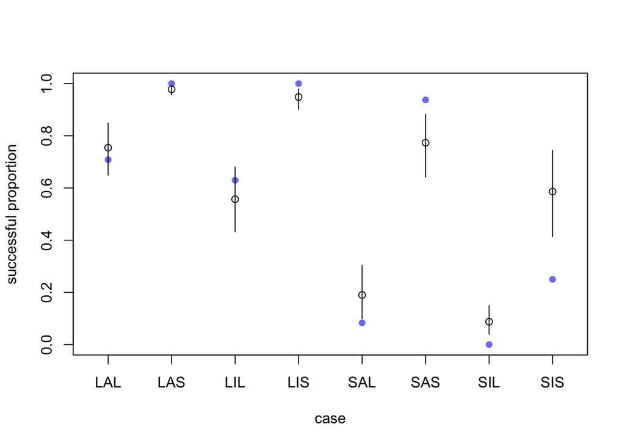

```r
d$psuccess <- d$y / d$n
p <- link(m1_stan)
y <- sim(m1_stan)
p.mean <- apply( p , 2 , mean )
p.PI <- apply( p , 2 , PI )
y.mean <- apply( y , 2 , mean )
y.PI <- apply( y , 2 , PI )

# plot raw proportions success for each case
plot( d$psuccess , col=rangi2 ,
ylab="successful proportion" , xlab="case" , xaxt="n" ,
xlim=c(0.75,8.25) , pch=16 )
# label cases on horizontal axis
axis( 1 , at=1:8 ,
labels=c( "LAL","LAS","LIL","LIS","SAL","SAS","SIL","SIS" ) )
# display posterior predicted proportions successful
points( 1:8 , p.mean )
for ( i in 1:8 ) lines( c(i,i) , p.PI[,i] )
```

**And here’s the second plot, showing number of successes on the vertical:**

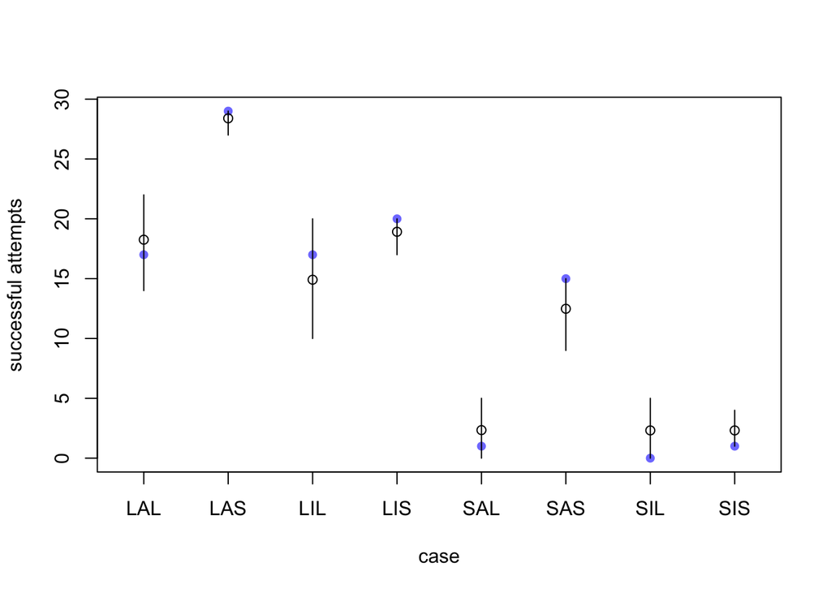

```r
# plot raw counts success for each case
plot( d$y , col=rangi2 ,
ylab="successful attempts" , xlab="case" , xaxt="n" ,
xlim=c(0.75,8.25) , pch=16 )
# label cases on horizontal axis
axis( 1 , at=1:8 ,
labels=c( "LAL","LAS","LIL","LIS","SAL","SAS","SIL","SIS" ) )
# display posterior predicted successes
points( 1:8 , y.mean )
for ( i in 1:8 ) lines( c(i,i) , y.PI[,i] )
```

**So what’s different? The biggest difference is probably that the left plot (proportions) makes the probabilities more comparable, because it ignores the sample size for each case on the horizontal axis. This has the advantage of showing, for example, that SIS attempts are predicted to be somewhat successful, even though only 4 of them were observed. The right plot (counts), in contrast, makes it hard to see the differing probabilities, because samples size varies so much across cases. On the other hand, the count plot (right) has the advantage of showing additional uncertainty that arises from the binomial process. Inspect the SIS case again, for example. The observed proportion of SIS successes is outside and below the probability interval (left plot). However, in the bottom plot, the model can accommodate the SIS cases, due to additional uncertainty arising from the binomial process. In other words, an additional level of stochasticity is factored into the bottom plot, and so in total looking also at counts might be necessary to seriously critique the model.**

3. Now try to improve the model. Consider an interaction between the pirate’s size and age (immature or adult). Compare this model to the previous one, using WAIC. Interpret.

**The two models to compare are the one you fit before, with the three main effects, and the new one, including the interaction P ×A. Here is the code to fit the models and compare them:**

```r
m2 <- ulam(
alist(
y ~ dbinom( n , p ),
logit(p) <- a + bP*pirateL + bV*victimL +
bA*pirateA + bPA*pirateL*pirateA ,
a ~ dnorm(0,1.5),
bP ~ dnorm(0,1),
bV ~ dnorm(0,1),
bA ~ dnorm(0,1),
bPA ~ dnorm(0,1)
) , data=d , chains=4 , log_lik=TRUE )
```

[output not shown]

```r
compare( m1_stan , m2 )
```

|  | WAIC | SE | dWAIC | dSE | pWAIC | weight |
| --- | --- | --- | --- | --- | --- | --- |
| m1_stan | 36.23201 | 5.360055 | 0.0000000 | NA | 4.680011 | 0.6043143 |
| m2 | 37.07896 | 5.131926 | 0.8469485 | 0.5834076 | 5.274453 | 0.3956857 |

**This seems to be a tie. Let’s look at the estimates for the interaction model:**

```r
precis(m2)
```

|  | mean | sd | 5.5% | 94.5% | rhat | ess_bulk |
| --- | --- | --- | --- | --- | --- | --- |
| a | 0.2995657 | 0.5217942 | -0.5496031 | 1.1499998 | 1.002985 | 826.3221 |
| bP | 2.7409716 | 0.4995236 | 1.9626553 | 3.5754781 | 1.001890 | 941.7861 |
| bV | -2.7736294 | 0.4722640 | -3.5310530 | -2.0596709 | 1.000992 | 1151.8655 |
| bA | 1.0241884 | 0.5119862 | 0.2239066 | 1.8797154 | 1.003268 | 937.5477 |
| bPA | -0.1798073 | 0.6056541 | -1.1451691 | 0.7977302 | 1.002593 | 886.9280 |

**So when the pirate is both large and adult, the log-odds are smaller. This seems like a weird result. Shouldn’t being large and adult help? It does. But the main effects for size and age are also turned on, when an individual is both large and adult. So it’s hard to understand what the model is saying, without computing predictions case by case. However, the predictions are essentially the same as the previous model. There just isn’t enough data here to support any confident inference about an interaction.**

12H2. Counts are nearly always over-dispersed relative to Poisson. So fit a gamma-Poisson (aka negative-binomial) model to predict deaths using femininity. Show that the over-dispersed model no longer shows as precise a positive association between femininity and deaths, with an 89% interval that overlaps zero. Can you explain why the association diminished in strength?

**To deal with the over-dispersion seen in the previous problem, now we’ll fit a Poisson model with varying rates, a gamma-Poisson model. This code will set up the data (just as in the previous problem) and fit the gamma-Poisson model:**

```r
library(rethinking)
data(Hurricanes)
d <- Hurricanes
d$fmnnty_std <- ( d$femininity - mean(d$femininity) )/sd(d$femininity)
dat <- list( D=d$deaths , F=d$fmnnty_std)

m2 <- ulam(
alist(
D ~ dgampois( lambda , scale ),
log(lambda) <- a + bF*F,
a ~ dnorm(1,1),
bF ~ dnorm(0,1),
scale ~ dexp(1)
), data=dat , chains=4 , log_lik=TRUE )
```

[output not shown]

[output not shown]

[output not shown]

[output not shown]

[output not shown]

```
## Chain 1
```

[output not shown]

[output not shown]

[output not shown]

[output not shown]

[output not shown]

```
## Chain 2
```

[output not shown]

[output not shown]

[output not shown]

[output not shown]

```
## Chain 2
```

[output not shown]

[output not shown]

[output not shown]

[output not shown]

```
## Chain 2
```

[output not shown]

[output not shown]

[output not shown]

[output not shown]

[output not shown]

```
## Chain 3
```

[output not shown]

[output not shown]

[output not shown]

[output not shown]

[output not shown]

```
## Chain 4
```

[output not shown]

**Inspect the marginal posterior distributions of the parameters:**

```r
precis(m2)
```

|  | mean | sd | 5.5% | 94.5% | rhat | ess_bulk |
| --- | --- | --- | --- | --- | --- | --- |
| a | 2.9676857 | 0.14841750 | 2.73853340 | 3.2034187 | 1.003438 | 1719.130 |
| bF | 0.2122995 | 0.14811426 | -0.02665129 | 0.4401316 | 1.002391 | 1821.263 |
| scale | 0.4546527 | 0.06295769 | 0.36048562 | 0.5632550 | 1.005480 | 1875.565 |

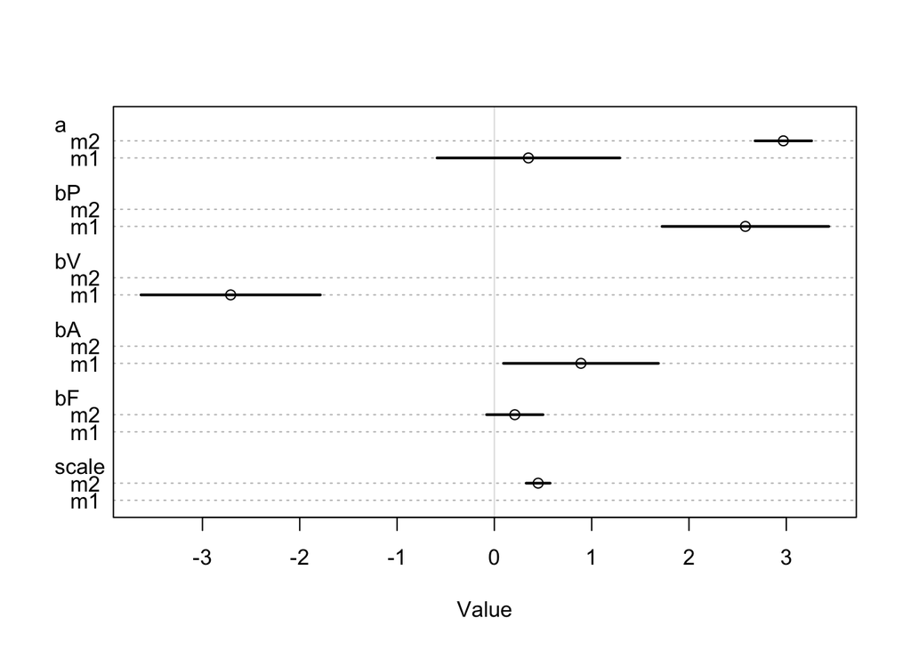

```r
plot(coeftab(m1,m2))
```

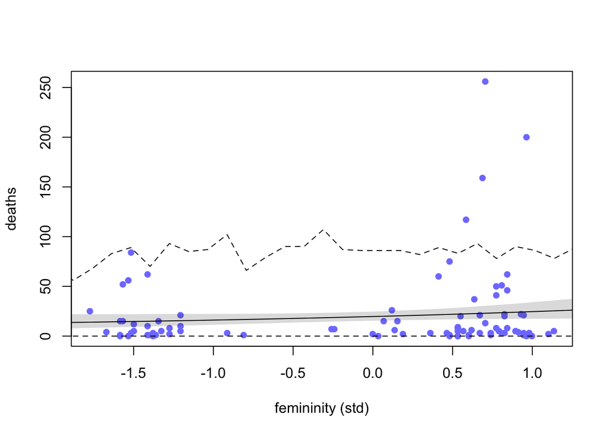

```r
# plot raw data
plot( dat$F , dat$D , pch=16 , lwd=2 ,
col=rangi2 , xlab="femininity (std)" , ylab="deaths" )
# compute model-based trend
pred_dat <- list( F=seq(from=-2,to=1.5,length.out=30) )
lambda <- link(m2,data=pred_dat)
lambda.mu <- apply(lambda,2,mean)
lambda.PI <- apply(lambda,2,PI)
# superimpose trend
lines( pred_dat$F , lambda.mu )
shade( lambda.PI , pred_dat$F )
# compute sampling distribution
deaths_sim <- sim(m2,data=pred_dat)
deaths_sim.PI <- apply(deaths_sim,2,PI)
# superimpose sampling interval as dashed lines
lines( pred_dat$F , deaths_sim.PI[1,] , lty=2 )
lines( pred_dat$F , deaths_sim.PI[2,] , lty=2 )
```

**There is more uncertainty now about the relationship, and the prediction interval is wider. But the predictions are still terrible. Now for the conceptual part of this problem: Why does including varying rates, via the gamma distribution, result in greater uncertainty in the relationship? The gamma-Poisson model allows each hurricane to have its own unique expected death rate, sampled from a common distribution that is a function of the femininity of hurricane names. We can actually plot this distribution from the posterior distribution, for any given femininity value. I’ll produce three examples, plotting 100 randomly sampled gamma distributions of the rate of deaths for three different femininity values:**

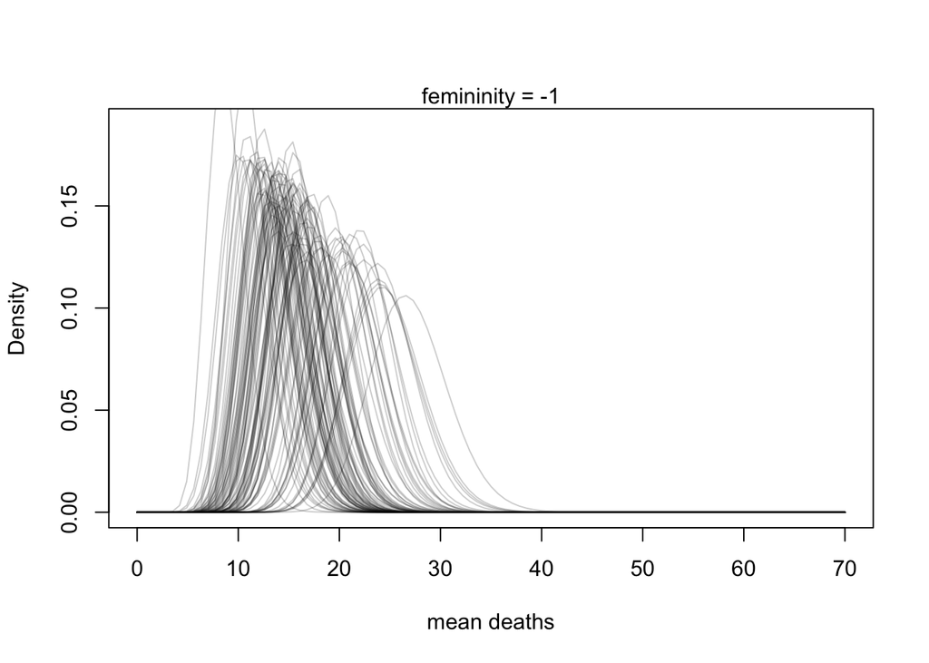

```r
post <- extract.samples(m2)
fem <- (-1) # 1 stddev below mean
for ( i in 1:100 )
curve( dgamma2(x,exp(post$a[i]+post$bF[i]*fem),post$scale[i]) ,
from=0 , to=70 , xlab="mean deaths" , ylab="Density" ,
ylim=c(0,0.19) , col=col.alpha("black",0.2) ,
add=ifelse(i==1,FALSE,TRUE) )
mtext( concat("femininity = ",fem) )
```

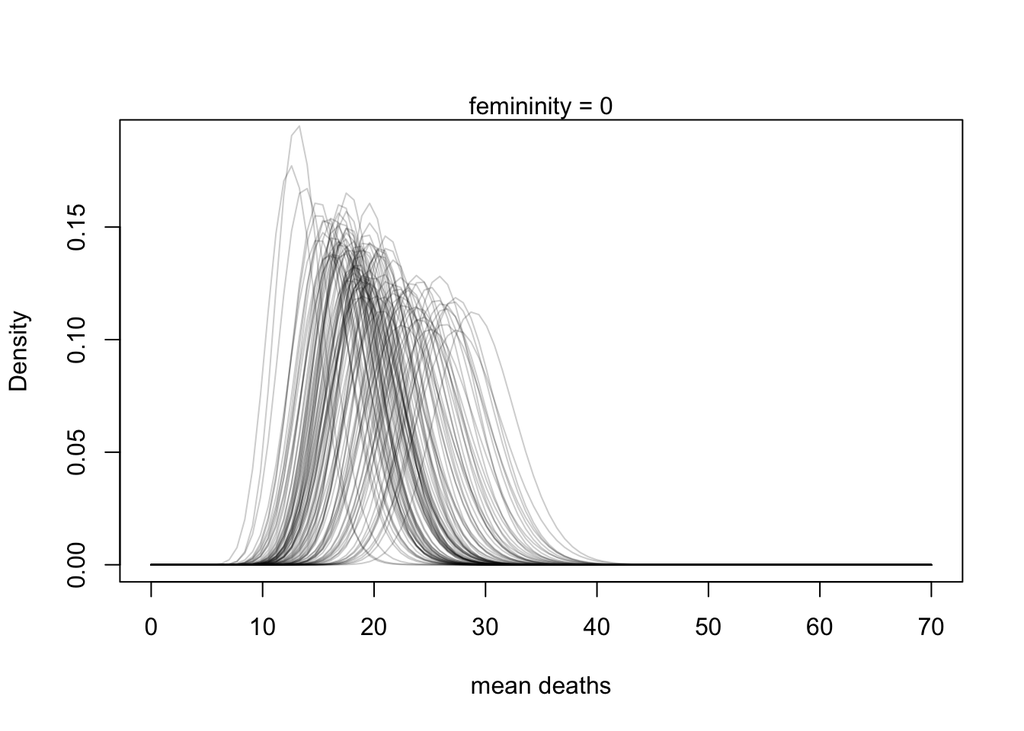

```r
post <- extract.samples(m2)
fem <- (0) # 1 stddev below mean
for ( i in 1:100 )
curve( dgamma2(x,exp(post$a[i]+post$bF[i]*fem),post$scale[i]) ,
from=0 , to=70 , xlab="mean deaths" , ylab="Density" ,
ylim=c(0,0.19) , col=col.alpha("black",0.2) ,
add=ifelse(i==1,FALSE,TRUE) )
mtext( concat("femininity = ",fem) )
```

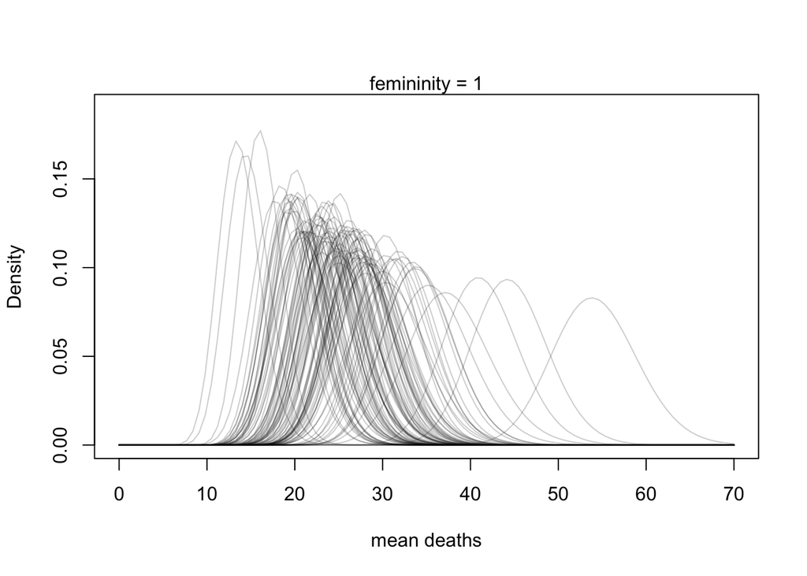

```r
post <- extract.samples(m2)
fem <- (1) # 1 stddev below mean
for ( i in 1:100 )
curve( dgamma2(x,exp(post$a[i]+post$bF[i]*fem),post$scale[i]) ,
from=0 , to=70 , xlab="mean deaths" , ylab="Density" ,
ylim=c(0,0.19) , col=col.alpha("black",0.2) ,
add=ifelse(i==1,FALSE,TRUE) )
mtext( concat("femininity = ",fem) )
```

13H4. Revisit the Reed frog survival data, data(reedfrogs), and add the predation and size treatment variables to the varying intercepts model. Consider models with either predictor alone, both predictors, as well as a model including their interaction. What do you infer about the causal influence of these predictor variables? Also focus on the inferred variation across tanks (the σ across tanks). Explain why it changes as it does across models with different predictors included.

**This problem is very similar to 13M1, but it asks for interpretation of the posterior distribution. The same code is needed. Run the models from that solution again. Then let’s inspect the posterior distributions of the coefficients. First the model with only predation:**

**Running the models for 13M1**

```r
library(rethinking)
data(reedfrogs)
d <- reedfrogs
dat <- list(
S = d$surv,
n = d$density,
tank = 1:nrow(d),
pred = ifelse( d$pred=="no" , 0L , 1L ),
size_ = ifelse( d$size=="small" , 1L , 2L )
)

m1.1 <- ulam(
alist(
S ~ binomial( n , p ),
logit(p) <- a[tank],
a[tank] ~ normal( a_bar , sigma ),
a_bar ~ normal( 0 , 1.5 ),
sigma ~ exponential( 1 )
), data=dat , chains=4 , cores=4 , log_lik=TRUE )
```

[output not shown]

```r
# pred
m1.2 <- ulam(
alist(
S ~ binomial( n , p ),
logit(p) <- a[tank] + bp*pred,
a[tank] ~ normal( a_bar , sigma ),
bp ~ normal( -0.5 , 1 ),
a_bar ~ normal( 0 , 1.5 ),
sigma ~ exponential( 1 )
), data=dat , chains=4 , cores=4 , log_lik=TRUE )
```

[output not shown]

[output not shown]

[output not shown]

[output not shown]

[output not shown]

```
## Chain 3
```

[output not shown]

```r
# size
m1.3 <- ulam(
alist(
S ~ binomial( n , p ),
logit(p) <- a[tank] + s[size_],
a[tank] ~ normal( a_bar , sigma ),
s[size_] ~ normal( 0 , 0.5 ),
a_bar ~ normal( 0 , 1.5 ),
sigma ~ exponential( 1 )
), data=dat , chains=4 , cores=4 , log_lik=TRUE )
```

[output not shown]

[output not shown]

[output not shown]

[output not shown]

[output not shown]

```
## Chain 3
```

[output not shown]

```r
# pred + size
m1.4 <- ulam(
alist(
S ~ binomial( n , p ),
logit(p) <- a[tank] + bp*pred + s[size_],
a[tank] ~ normal( a_bar , sigma ),
bp ~ normal( -0.5 , 1 ),
s[size_] ~ normal( 0 , 0.5 ),
a_bar ~ normal( 0 , 1.5 ),
sigma ~ exponential( 1 )
), data=dat , chains=4 , cores=4 , log_lik=TRUE )
```

[output not shown]

```r
# pred + size + interaction
m1.5 <- ulam(
alist(
S ~ binomial( n , p ),
logit(p) <- a_bar + z[tank]*sigma + bp[size_]*pred + s[size_],
z[tank] ~ normal( 0 , 1 ),
bp[size_] ~ normal( -0.5 , 1 ),
s[size_] ~ normal( 0 , 0.5 ),
a_bar ~ normal( 0 , 1.5 ),
sigma ~ exponential( 1 )
), data=dat , chains=4 , cores=4 , log_lik=TRUE )
```

[output not shown]

```r
precis( m1.2 )
```

```
## 48 vector or matrix parameters hidden. Use depth=2 to show them.
```

|  | mean | sd | 5.5% | 94.5% | rhat | ess_bulk |
| --- | --- | --- | --- | --- | --- | --- |
| bp | -2.4067418 | 0.3026441 | -2.8952920 | -1.915466 | 1.021856 | 230.1615 |
| a_bar | 2.5157600 | 0.2375340 | 2.1333697 | 2.893396 | 1.021004 | 261.2479 |
| sigma | 0.8226285 | 0.1484564 | 0.6137908 | 1.076178 | 1.007456 | 614.5210 |

**Predation has a very strong negative effect on survival, which makes sense. Now consider the model that omits predation but includes size:**

```r
precis( m1.3 , 2 , pars="s" )
```

|  | mean | sd | 5.5% | 94.5% | rhat | ess_bulk |
| --- | --- | --- | --- | --- | --- | --- |
| s[1] | 0.1935455 | 0.3863298 | -0.4288592 | 0.8238778 | 1.007058 | 233.6590 |
| s[2] | -0.1033691 | 0.3930764 | -0.7392826 | 0.5384988 | 1.010348 | 259.7505 |

**Not such a clear effect of size. Now let’s consider the models that include both. First the model without an interaction:**

```r
precis( m1.4 , 2 , pars=c("bp","s") )
```

|  | mean | sd | 5.5% | 94.5% | rhat | ess_bulk |
| --- | --- | --- | --- | --- | --- | --- |
| bp | -2.4679355 | 0.2903449 | -2.9229032 | -1.9962945 | 1.000894 | 713.9024 |
| s[1] | 0.3113644 | 0.3686253 | -0.2685616 | 0.8891827 | 1.017176 | 217.0845 |
| s[2] | -0.1251710 | 0.3543340 | -0.6674256 | 0.4526465 | 1.015393 | 216.9497 |

**The agrees with the previous models. Predation has a clear and large impact. Size not so much. Now the interaction model:**

```r
precis( m1.5 , 2 , pars=c("bp","s") )
```

|  | mean | sd | 5.5% | 94.5% | rhat | ess_bulk |
| --- | --- | --- | --- | --- | --- | --- |
| bp[1] | -1.854869 | 0.3851214 | -2.4612850 | -1.2212315 | 1.004158 | 892.7847 |
| bp[2] | -2.719893 | 0.3904602 | -3.3333532 | -2.0803993 | 1.002546 | 807.4806 |
| s[1] | 0.138062 | 0.3874159 | -0.4829623 | 0.7469239 | 1.001531 | 974.3808 |
| s[2] | 0.170957 | 0.3929463 | -0.4326741 | 0.7947648 | 1.001616 | 1095.7033 |

**The effect of predation does seem to vary by size. Let’s compute the contrast:**

```r
post <- extract.samples( m1.5 )
quantile( post$bp[,2] - post$bp[,1] , c(0.055,0.5,0.945) )
```

```
##       5.5%        50%      94.5%
## -1.6749201 -0.8508550 -0.0663939
```

**So the contrast is reliably negative. Seems like size does matter, but only as it influences predation.**

16H5. Population dynamic models are typically very difficult to fit to empirical data. The lynx-hare example in the chapter was easy, partly because the data are unusually simple and partly because the chapter did the difficult prior selection for you. Here’s another data set that will impress upon you both how hard the task can be and how badly Lotka-Volterra fits empirical data in general. The data in data(Mites) are numbers of predator and prey mites living on fruit. Model these data using the same Lotka-Volterra ODE system from the chapter. These data are actual counts of individuals, not just their pelts. You will need to adapt the Stan code in data(Lynx_Hare_model). Note that the priors will need to be rescaled, because the outcome variables are on a different scale. Prior predictive simulation will help. Keep in mind as well that the time variable and the birth and death parameters go together. If you rescale the time dimension, that implies you must also rescale the parameters.

**Let’s begin by just loading the data and plotting it:**

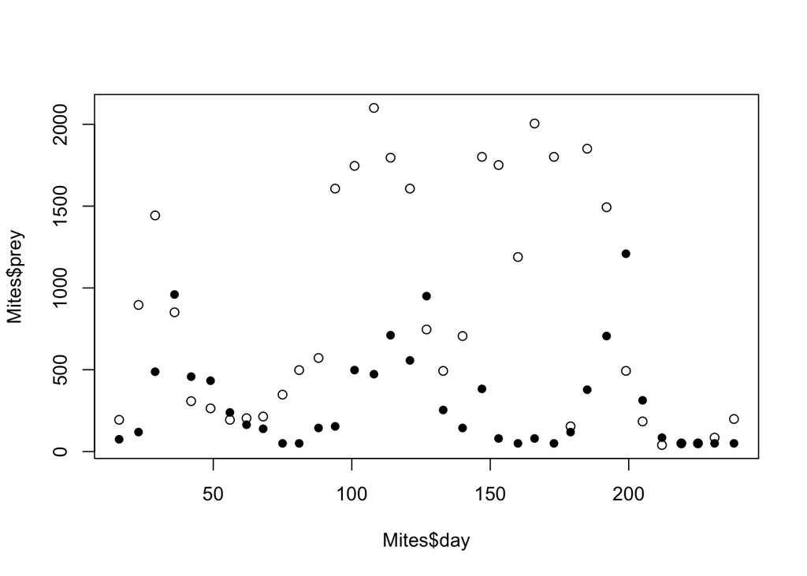

```r
library(rethinking)
data(Mites)

plot( Mites$day , Mites$prey )
points( Mites$day , Mites$predator , pch=16 )
```

**The horizontal axis is day in the experiment and the vertical axis is count of individuals. The open circles are prey and the filled circles are predators. There does seem to be some kind of cycle there, maybe. We need to build the model and we need priors. The model is actually simpler than the one in the book, because there won’t be a measurement layer. We have actual mite counts here, not some error- prone proxy like pelts. Let’s start with the priors, simulating the true counts as we did in the chapter. If you play around, you can find some priors that will produce cycles. We need the simulation function from the chapter:**

```r
sim_mites <- function( n_steps , init , theta , dt=0.002 ) {
L <- rep(NA,n_steps)
H <- rep(NA,n_steps)
L[1] <- init[1]
H[1] <- init[2]
for ( i in 2:n_steps ) {
L[i] <- L[i-1] + dt*L[i-1]*( theta[3]*H[i-1] - theta[4] )
H[i] <- H[i-1] + dt*H[i-1]*( theta[1] - theta[2]*L[i-1] )
}
return( cbind(L,H) )
}
```

**And here are some priors with code to simulate and plot:**

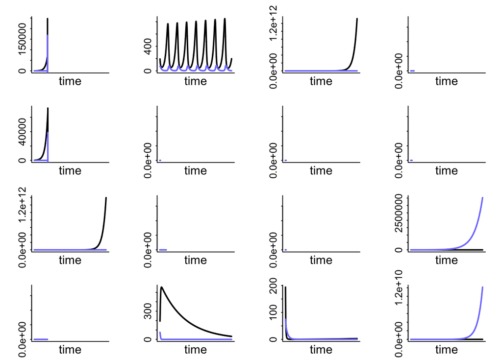

```r
N <- 16
theta <- matrix( NA , N , 4 )
theta[,1] <- rnorm( N , 1.5 , 1 )
theta[,2] <- rnorm( N , 0.005 , 0.1 )
theta[,3] <- rnorm( N , 0.0005 , 0.1 )
theta[,4] <- rnorm( N , 0.5 , 1 )
par(mfrow=c(4,4),cex=1.05)
par(mgp = c(1, 0.2, 0), mar = c(1, 2, 1, 1) + 0.1,
tck = -0.02, cex.axis = 0.8, bty = "l" )
for ( i in 1:N ) {
z <- sim_mites( n_steps=1e4 , init=as.numeric(Mites[1,3:2]) , theta=theta[i,] )
# preds in blue, prey in black
ymax <- max(z)
if ( ymax == Inf ) ymax <- 1.79e+300
plot( NULL , ylim=c(0,ymax) , xlim=c(0,1e4) , xaxt="n" , ylab="" , xlab="" )
lines( z[,2] , col="black" , lwd=2 )
lines( z[,1] , col=rangi2 , lwd=2 )
mtext( "time" , 1 )
}
```

**Here is the Stan code as an R character vector:**

```r
mites_model_code <- "
functions {
  vector dpop_dt(real t,
                 vector pop_init,
                 array[] real theta) {
    real L = pop_init[1];
    real H = pop_init[2];
    real bh = theta[1];
    real mh = theta[2];
    real ml = theta[3];
    real bl = theta[4];

    vector[2] dpop;
    dpop[1] = (bl * H - ml) * L;  // dL_dt
    dpop[2] = (bh - mh * L) * H;  // dH_dt

    return dpop;
  }
}

data {
  int<lower=0> N;
  array[N, 2] int<lower=0> mites;
  array[N] real<lower=0> days;
}

parameters {
  array[4] real<lower=0> theta;
  array[2] real<lower=0> pop_init;
  array[2] real<lower=0> sigma;
}

transformed parameters {
  array[N, 2] real pop;

  pop[1, 1] = pop_init[1];
  pop[1, 2] = pop_init[2];

  if (N > 1) {
    array[N-1] vector[2] pop_integrated;
    pop_integrated = ode_rk45(dpop_dt, to_vector(pop_init), 0, days[2:N], theta);

    for (i in 2:N) {
      pop[i, 1] = pop_integrated[i-1][1];
      pop[i, 2] = pop_integrated[i-1][2];
    }
  }
}

model {
  theta[1] ~ normal(1.5, 1);
  theta[2] ~ normal(0.005, 0.1);
  theta[3] ~ normal(0.0005, 0.1);
  theta[4] ~ normal(0.5, 1);
  sigma ~ exponential(1);
  pop_init[1] ~ normal(mites[1, 1], 50);
  pop_init[2] ~ normal(mites[1, 2], 50);

  for (t in 1:N) {
    for (k in 1:2) {
      mites[t, k] ~ lognormal(log(pop[t, k]), sigma[k]);
    }
  }
}

generated quantities {
  array[N, 2] real mites_pred;
  for (t in 1:N) {
    for (k in 1:2) {
      mites_pred[t, k] = lognormal_rng(log(pop[t, k]), sigma[k]);
    }
  }
}
"
```

**Now we can prepare the data and run the model:**

```r
dat_mites <- list(
N = nrow(Mites),
mites = as.matrix( Mites[,3:2] ),
days = Mites[,1]/7 )

m16H5.1 <- stan( model_code=mites_model_code , data=dat_mites , chains=4 , cores=4 , iter=2000 ,control=list( adapt_delta=0.99 ) )
```

[output not shown]

[output not shown]

[output not shown]

[output not shown]

[output not shown]

[output not shown]

[output not shown]

[output not shown]

[output not shown]

[output not shown]

[output not shown]

[output not shown]

[output not shown]

[output not shown]

[output not shown]

[output not shown]

[output not shown]

[output not shown]

[output not shown]

[output not shown]

[output not shown]

[output not shown]

[output not shown]

[output not shown]

[output not shown]

[output not shown]

[output not shown]

[output not shown]

[output not shown]

[output not shown]

[output not shown]

[output not shown]

[output not shown]

[output not shown]

[output not shown]

[output not shown]

[output not shown]

[output not shown]

[output not shown]

[output not shown]

[output not shown]

[output not shown]

[output not shown]

[output not shown]

[output not shown]

[output not shown]

[output not shown]

[output not shown]

[output not shown]

[output not shown]

[output not shown]

[output not shown]

[output not shown]

[output not shown]

[output not shown]

[output not shown]

[output not shown]

[output not shown]

[output not shown]

[output not shown]

[output not shown]

[output not shown]

[output not shown]

[output not shown]

[output not shown]

[output not shown]

[output not shown]

[output not shown]

[output not shown]

[output not shown]

[output not shown]

[output not shown]

[output not shown]

[output not shown]

[output not shown]

[output not shown]

[output not shown]

[output not shown]

[output not shown]

[output not shown]

[output not shown]

[output not shown]

[output not shown]

[output not shown]

[output not shown]

[output not shown]

[output not shown]

[output not shown]

[output not shown]

[output not shown]

[output not shown]

[output not shown]

[output not shown]

[output not shown]

[output not shown]

[output not shown]

[output not shown]

[output not shown]

[output not shown]

[output not shown]

[output not shown]

[output not shown]

[output not shown]

[output not shown]

[output not shown]

[output not shown]

[output not shown]

[output not shown]

[output not shown]

[output not shown]

[output not shown]

[output not shown]

[output not shown]

[output not shown]

[output not shown]

[output not shown]

[output not shown]

[output not shown]

[output not shown]

[output not shown]

[output not shown]

[output not shown]

[output not shown]

[output not shown]

[output not shown]

[output not shown]

[output not shown]

[output not shown]

[output not shown]

[output not shown]

[output not shown]

[output not shown]

[output not shown]

[output not shown]

[output not shown]

[output not shown]

[output not shown]

[output not shown]

[output not shown]

[output not shown]

[output not shown]

[output not shown]

[output not shown]

[output not shown]

[output not shown]

[output not shown]

[output not shown]

[output not shown]

[output not shown]

[output not shown]

[output not shown]

[output not shown]

[output not shown]

[output not shown]

[output not shown]

[output not shown]

[output not shown]

[output not shown]

[output not shown]

[output not shown]

[output not shown]

[output not shown]

[output not shown]

[output not shown]

[output not shown]

[output not shown]

[output not shown]

[output not shown]

[output not shown]

[output not shown]

[output not shown]

[output not shown]

[output not shown]

[output not shown]

[output not shown]

[output not shown]

[output not shown]

[output not shown]

[output not shown]

[output not shown]

[output not shown]

[output not shown]

[output not shown]

[output not shown]

[output not shown]

[output not shown]

[output not shown]

[output not shown]

[output not shown]

[output not shown]

[output not shown]

[output not shown]

[output not shown]

[output not shown]

[output not shown]

[output not shown]

[output not shown]

[output not shown]

[output not shown]

[output not shown]

[output not shown]

[output not shown]

[output not shown]

[output not shown]

[output not shown]

[output not shown]

[output not shown]

[output not shown]

[output not shown]

[output not shown]

[output not shown]

[output not shown]

[output not shown]

[output not shown]

[output not shown]

[output not shown]

[output not shown]

[output not shown]

[output not shown]

[output not shown]

[output not shown]

[output not shown]

[output not shown]

[output not shown]

[output not shown]

[output not shown]

[output not shown]

[output not shown]

[output not shown]

[output not shown]

[output not shown]

[output not shown]

[output not shown]

[output not shown]

[output not shown]

[output not shown]

[output not shown]

[output not shown]

[output not shown]

[output not shown]

[output not shown]

[output not shown]

[output not shown]

[output not shown]

[output not shown]

[output not shown]

[output not shown]

[output not shown]

[output not shown]

[output not shown]

[output not shown]

[output not shown]

[output not shown]

[output not shown]

[output not shown]

[output not shown]

[output not shown]

[output not shown]

[output not shown]

[output not shown]

[output not shown]

[output not shown]

[output not shown]

[output not shown]

[output not shown]

[output not shown]

[output not shown]

[output cut: 13 more lines]

[output not shown]

```r
# If using an external text file:
# m16H5.1 <- stan( file="Mites.stan" , data=dat_mites , chains=4 , cores=4 , iter=2000 ,control=list( adapt_delta=0.99 ) )

precis(m16H5.1,2)
```

```
## 140 matrix parameters hidden. Use depth=3 to show them.
```

|  | mean | sd | 5.5% | 94.5% | rhat | ess_bulk |
| --- | --- | --- | --- | --- | --- | --- |
| theta[1] | 1.48121936 | 0.55347553 | 6.353918e-01 | 2.1619500 | 1.344671 | 9.975368 |
| theta[2] | 0.04826701 | 0.07171512 | 3.654529e-03 | 0.1723780 | 1.627566 | 7.013149 |
| theta[3] | 0.24907261 | 0.13675974 | 1.403285e-02 | 0.4097712 | 2.438614 | 7.129966 |
| theta[4] | 0.72052982 | 1.24756890 | 2.950054e-05 | 2.8811800 | 2.682347 | 4.703560 |
| pop_init[1] | 95.72230807 | 59.81619402 | 6.861320e-01 | 172.9512650 | 1.879702 | 5.733189 |
| pop_init[2] | 175.23812437 | 106.64485368 | 5.458580e+00 | 300.8612750 | 1.774707 | 5.989656 |
| sigma[1] | 1.01820136 | 0.33801273 | 5.938945e-01 | 1.5033306 | 2.062900 | 5.340299 |
| sigma[2] | 0.88242296 | 0.29455125 | 4.221260e-01 | 1.2531859 | 1.674855 | 6.347373 |

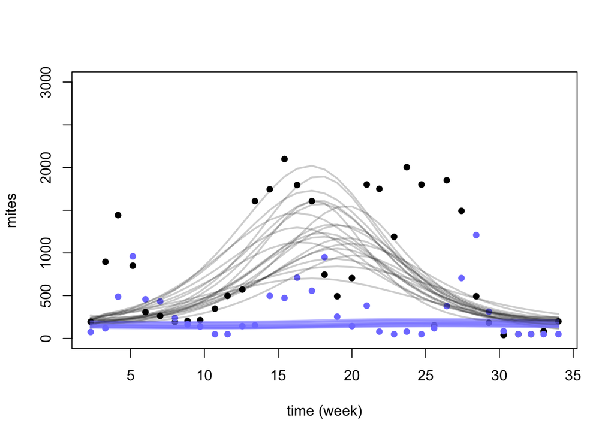

```r
post <- extract.samples(m16H5.1)
mites <- dat_mites$mites
plot( dat_mites$days , mites[,2] , pch=16 , ylim=c(0,3000) ,
xlab="time (week)" , ylab="mites" )
points( dat_mites$days , mites[,1] , col=rangi2 , pch=16 )
for ( s in 1:21 ) {
lines( dat_mites$days , post$pop[s,,2] , col=col.alpha("black",0.2) , lwd=2 )
lines( dat_mites$days , post$pop[s,,1] , col=col.alpha(rangi2,0.3) , lwd=2 )
}
```

**There are some clear problems here. Ecologists know that plain Lotka-Volterra models have trouble with realistic data. And these data are even an experiment. Better models have stochasticity in them, such that stochasticity in birth/death processes propagates through the dynamics. These models are deterministic, and so in small populations and spatially divided populations (like these mite experiments—go read the original paper), they can have clear problems. The important thing is to understand the structural features of each model that produce different dynamics. Real biology is too complicated to ever get the model right. But models are still essential for their study.**